# Moringa_Data_Science_Core_W13_Independent_Project_Moffat_Kirui_UnsupervisedLearning

# 1. Defining the Question

## a) Specifying the question

To learn the characteristics of customer groups by performing clustering.

## b) Defining the metric of success

Our project will be a success if we successfully group the customers into significant clusters.

## c) Understanding the context

Kira Plastinina is a Russian brand that is sold through a defunct chain of retail stores in Russia, Ukraine, Kazakhstan, Belarus, China, Philippines, and Armenia. The brand’s Sales and Marketing team would like to understand their customer’s behavior from data that they have collected over the past year. More specifically, they would like to learn the characteristics of customer groups.

## d) Recording the Experimental Design

- Problem Definition
- Data Sourcing
- Check the Data
- Perform Data Cleaning
- Perform Exploratory Data Analysis (Univariate, Bivariate & Multivariate)
- Implement the Solution
- Challenge the Solution
- Follow up Questions

## e) Data Relevance

- The dataset consists of 10 numerical and 8 categorical attributes. The ‘Revenue’ attribute can be used as the class label.
- “Administrative”, “Administrative Duration”, “Informational”, “Informational Duration”, “Product Related” and “Product Related Duration” represents the number of different types of pages visited by the visitor in that session and total time spent in each of these page categories. The values of these features are derived from the URL information of the pages visited by the user and updated in real-time when a user takes an action, e.g. moving from one page to another.
- The “Bounce Rate”, “Exit Rate” and “Page Value” features represent the metrics measured by “Google Analytics” for each page in the e-commerce site.
- The value of the “Bounce Rate” feature for a web page refers to the percentage of visitors who enter the site from that page and then leave (“bounce”) without triggering any other requests to the analytics server during that session.
- The value of the “Exit Rate” feature for a specific web page is calculated as for all pageviews to the page, the percentage that was the last in the session.
- The “Page Value” feature represents the average value for a web page that a user visited before completing an e-commerce transaction.
- The “Special Day” feature indicates the closeness of the site visiting time to a specific special day (e.g. Mother’s Day, Valentine’s Day) in which the sessions are more likely to be finalized with the transaction. The value of this attribute is determined by considering the dynamics of e-commerce such as the duration between the order date and delivery date. For example, for Valentina’s day, this value takes a nonzero value between February 2 and February 12, zero before and after this date unless it is close to another special day, and its maximum value of 1 on February 8.
- The dataset also includes the operating system, browser, region, traffic type, visitor type as returning or new visitor, a Boolean value indicating whether the date of the visit is weekend, and month of the year.

# 2. Reading the data

```r
library(tidyverse)
library(readr)
ecomm<- read_csv("http://bit.ly/EcommerceCustomersDataset")
```

# 3. Checking the data

```r
# Determining the no. of records in our dataset
#
dim(ecomm)
```

```
## [1] 12330    18
```

```r
# Previewing the top of our dataset
#
head(ecomm)
```

```
## # A tibble: 6 x 18
##   Administrative Administrative_D~ Informational Informational_D~ ProductRelated
##            <dbl>             <dbl>         <dbl>            <dbl>          <dbl>
## 1              0                 0             0                0              1
## 2              0                 0             0                0              2
## 3              0                -1             0               -1              1
## 4              0                 0             0                0              2
## 5              0                 0             0                0             10
## 6              0                 0             0                0             19
## # ... with 13 more variables: ProductRelated_Duration <dbl>, BounceRates <dbl>,
## #   ExitRates <dbl>, PageValues <dbl>, SpecialDay <dbl>, Month <chr>,
## #   OperatingSystems <dbl>, Browser <dbl>, Region <dbl>, TrafficType <dbl>,
## #   VisitorType <chr>, Weekend <lgl>, Revenue <lgl>
```

```r
# Previewing the bottom of our dataset
#
tail(ecomm)
```

```
## # A tibble: 6 x 18
##   Administrative Administrative_D~ Informational Informational_D~ ProductRelated
##            <dbl>             <dbl>         <dbl>            <dbl>          <dbl>
## 1              0                 0             1                0             16
## 2              3               145             0                0             53
## 3              0                 0             0                0              5
## 4              0                 0             0                0              6
## 5              4                75             0                0             15
## 6              0                 0             0                0              3
## # ... with 13 more variables: ProductRelated_Duration <dbl>, BounceRates <dbl>,
## #   ExitRates <dbl>, PageValues <dbl>, SpecialDay <dbl>, Month <chr>,
## #   OperatingSystems <dbl>, Browser <dbl>, Region <dbl>, TrafficType <dbl>,
## #   VisitorType <chr>, Weekend <lgl>, Revenue <lgl>
```

```r
# Checking whether each column has an appropriate datatype
#
str(ecomm)
```

```
## spec_tbl_df [12,330 x 18] (S3: spec_tbl_df/tbl_df/tbl/data.frame)
##  $ Administrative         : num [1:12330] 0 0 0 0 0 0 0 1 0 0 ...
##  $ Administrative_Duration: num [1:12330] 0 0 -1 0 0 0 -1 -1 0 0 ...
##  $ Informational          : num [1:12330] 0 0 0 0 0 0 0 0 0 0 ...
##  $ Informational_Duration : num [1:12330] 0 0 -1 0 0 0 -1 -1 0 0 ...
##  $ ProductRelated         : num [1:12330] 1 2 1 2 10 19 1 1 2 3 ...
##  $ ProductRelated_Duration: num [1:12330] 0 64 -1 2.67 627.5 ...
##  $ BounceRates            : num [1:12330] 0.2 0 0.2 0.05 0.02 ...
##  $ ExitRates              : num [1:12330] 0.2 0.1 0.2 0.14 0.05 ...
##  $ PageValues             : num [1:12330] 0 0 0 0 0 0 0 0 0 0 ...
##  $ SpecialDay             : num [1:12330] 0 0 0 0 0 0 0.4 0 0.8 0.4 ...
##  $ Month                  : chr [1:12330] "Feb" "Feb" "Feb" "Feb" ...
##  $ OperatingSystems       : num [1:12330] 1 2 4 3 3 2 2 1 2 2 ...
##  $ Browser                : num [1:12330] 1 2 1 2 3 2 4 2 2 4 ...
##  $ Region                 : num [1:12330] 1 1 9 2 1 1 3 1 2 1 ...
##  $ TrafficType            : num [1:12330] 1 2 3 4 4 3 3 5 3 2 ...
##  $ VisitorType            : chr [1:12330] "Returning_Visitor" "Returning_Visitor" "Returning_Visitor" "Returning_Visitor" ...
##  $ Weekend                : logi [1:12330] FALSE FALSE FALSE FALSE TRUE FALSE ...
##  $ Revenue                : logi [1:12330] FALSE FALSE FALSE FALSE FALSE FALSE ...
##  - attr(*, "spec")=
##   .. cols(
##   ..   Administrative = col_double(),
##   ..   Administrative_Duration = col_double(),
##   ..   Informational = col_double(),
##   ..   Informational_Duration = col_double(),
##   ..   ProductRelated = col_double(),
##   ..   ProductRelated_Duration = col_double(),
##   ..   BounceRates = col_double(),
##   ..   ExitRates = col_double(),
##   ..   PageValues = col_double(),
##   ..   SpecialDay = col_double(),
##   ..   Month = col_character(),
##   ..   OperatingSystems = col_double(),
##   ..   Browser = col_double(),
##   ..   Region = col_double(),
##   ..   TrafficType = col_double(),
##   ..   VisitorType = col_character(),
##   ..   Weekend = col_logical(),
##   ..   Revenue = col_logical()
##   .. )
```

# 4. Tidying the dataset

```r
# Checking whether there are missing values in each column
colSums(is.na(ecomm))
```

```
##          Administrative Administrative_Duration           Informational
##                      14                      14                      14
##  Informational_Duration          ProductRelated ProductRelated_Duration
##                      14                      14                      14
##             BounceRates               ExitRates              PageValues
##                      14                      14                       0
##              SpecialDay                   Month        OperatingSystems
##                       0                       0                       0
##                 Browser                  Region             TrafficType
##                       0                       0                       0
##             VisitorType                 Weekend                 Revenue
##                       0                       0                       0
```

```r
# dropping null values
ecomm <-na.omit(ecomm)
```

```r
# checking for duplicates
anyDuplicated(ecomm)
```

```
## [1] 159
```

```r
#dealing with duplicates
ecomm<- ecomm[!duplicated(ecomm),]
```

```r
### checking for outliers, we only need the numerical columns

numcols <- ecomm[ ,1:10]
dev.new(width=10, height=5, unit="in")
invisible(lapply(1:ncol(numcols), function(i) boxplot(numcols[[i]],main = paste("Boxplot of" , colnames(numcols[,i])))))
```

[output not shown]

There were outliers in all the numerical values but since they were within the acceptable range of values we left them as they were.

# 5. Exploratory Data Analysis

## univariate analysis

### summary of the numerical variables

```r
summary(numcols)
```

```
##  Administrative  Administrative_Duration Informational
##  Min.   : 0.00   Min.   :  -1.00         Min.   : 0.0000
##  1st Qu.: 0.00   1st Qu.:   0.00         1st Qu.: 0.0000
##  Median : 1.00   Median :   9.00         Median : 0.0000
##  Mean   : 2.34   Mean   :  81.68         Mean   : 0.5088
##  3rd Qu.: 4.00   3rd Qu.:  94.75         3rd Qu.: 0.0000
##  Max.   :27.00   Max.   :3398.75         Max.   :24.0000
##  Informational_Duration ProductRelated   ProductRelated_Duration
##  Min.   :  -1.00        Min.   :  0.00   Min.   :   -1.0
##  1st Qu.:   0.00        1st Qu.:  8.00   1st Qu.:  193.6
##  Median :   0.00        Median : 18.00   Median :  609.5
##  Mean   :  34.84        Mean   : 32.06   Mean   : 1207.5
##  3rd Qu.:   0.00        3rd Qu.: 38.00   3rd Qu.: 1477.6
##  Max.   :2549.38        Max.   :705.00   Max.   :63973.5
##   BounceRates        ExitRates         PageValues        SpecialDay
##  Min.   :0.00000   Min.   :0.00000   Min.   :  0.000   Min.   :0.00000
##  1st Qu.:0.00000   1st Qu.:0.01422   1st Qu.:  0.000   1st Qu.:0.00000
##  Median :0.00293   Median :0.02500   Median :  0.000   Median :0.00000
##  Mean   :0.02045   Mean   :0.04150   Mean   :  5.952   Mean   :0.06197
##  3rd Qu.:0.01667   3rd Qu.:0.04848   3rd Qu.:  0.000   3rd Qu.:0.00000
##  Max.   :0.20000   Max.   :0.20000   Max.   :361.764   Max.   :1.00000
```

from the summary we found that some of the visit durations were -1 which is an anormalysince duartion cannot be negative therefore we decided to input the default value of zero.

```r
ecomm[ecomm == -1]<-0
```

```r
# describing numerical columns
library(psych)
description<- describe(numcols)
description
```

```
##                         vars     n    mean      sd median trimmed    mad min
## Administrative             1 12199    2.34    3.33   1.00    1.66   1.48   0
## Administrative_Duration    2 12199   81.68  177.53   9.00   42.87  13.34  -1
## Informational              3 12199    0.51    1.28   0.00    0.18   0.00   0
## Informational_Duration     4 12199   34.84  141.46   0.00    3.73   0.00  -1
## ProductRelated             5 12199   32.06   44.60  18.00   23.06  19.27   0
## ProductRelated_Duration    6 12199 1207.51 1919.93 609.54  832.36 745.12  -1
## BounceRates                7 12199    0.02    0.05   0.00    0.01   0.00   0
## ExitRates                  8 12199    0.04    0.05   0.03    0.03   0.02   0
## PageValues                 9 12199    5.95   18.66   0.00    1.33   0.00   0
## SpecialDay                10 12199    0.06    0.20   0.00    0.00   0.00   0
##                              max    range skew kurtosis    se
## Administrative             27.00    27.00 1.95     4.63  0.03
## Administrative_Duration  3398.75  3399.75 5.59    50.09  1.61
## Informational              24.00    24.00 4.01    26.64  0.01
## Informational_Duration   2549.38  2550.38 7.54    75.45  1.28
## ProductRelated            705.00   705.00 4.33    31.04  0.40
## ProductRelated_Duration 63973.52 63974.52 7.25   136.57 17.38
## BounceRates                 0.20     0.20 3.15     9.25  0.00
## ExitRates                   0.20     0.20 2.23     4.62  0.00
## PageValues                361.76   361.76 6.35    64.93  0.17
## SpecialDay                  1.00     1.00 3.28     9.78  0.00
```

### frequency tables for the categorical variables

```r
cat_cols<- ecomm[,11:18]
library(epiDisplay)
dev.new(width=10, height=5, unit="in")
lapply(1:ncol(cat_cols), function(x) tab1(cat_cols[,x], sort.group = "decreasing", cum.percent = TRUE,main = colnames(cat_cols[,x])))
```

```
## [[1]]
## cat_cols[, x] :
##         Frequency Percent Cum. percent
## May          3328    27.3         27.3
## Nov          2983    24.5         51.7
## Mar          1853    15.2         66.9
## Dec          1706    14.0         80.9
## Oct           549     4.5         85.4
## Sep           448     3.7         89.1
## Aug           433     3.5         92.6
## Jul           432     3.5         96.2
## June          285     2.3         98.5
## Feb           182     1.5        100.0
##   Total     12199   100.0        100.0
##
## [[2]]
## cat_cols[, x] :
##         Frequency Percent Cum. percent
## 2            6536    53.6         53.6
## 1            2548    20.9         74.5
## 3            2530    20.7         95.2
## 4             478     3.9         99.1
## 8              75     0.6         99.7
## 6              19     0.2         99.9
## 7               7     0.1        100.0
## 5               6     0.0        100.0
##   Total     12199   100.0        100.0
##
## [[3]]
## cat_cols[, x] :
##         Frequency Percent Cum. percent
## 2            7878    64.6         64.6
## 1            2426    19.9         84.5
## 4             730     6.0         90.5
## 5             466     3.8         94.3
## 6             174     1.4         95.7
## 10            163     1.3         97.0
## 8             135     1.1         98.1
## 3             105     0.9         99.0
## 13             56     0.5         99.5
```

[output cut: 51 more lines]

```
##   Total               12199   100.0        100.0
##
## [[7]]
## cat_cols[, x] :
##         Frequency Percent Cum. percent
## FALSE        9343    76.6         76.6
## TRUE         2856    23.4        100.0
##   Total     12199   100.0        100.0
##
## [[8]]
## cat_cols[, x] :
##         Frequency Percent Cum. percent
## FALSE       10291    84.4         84.4
## TRUE         1908    15.6        100.0
##   Total     12199   100.0        100.0
```

### Histograms

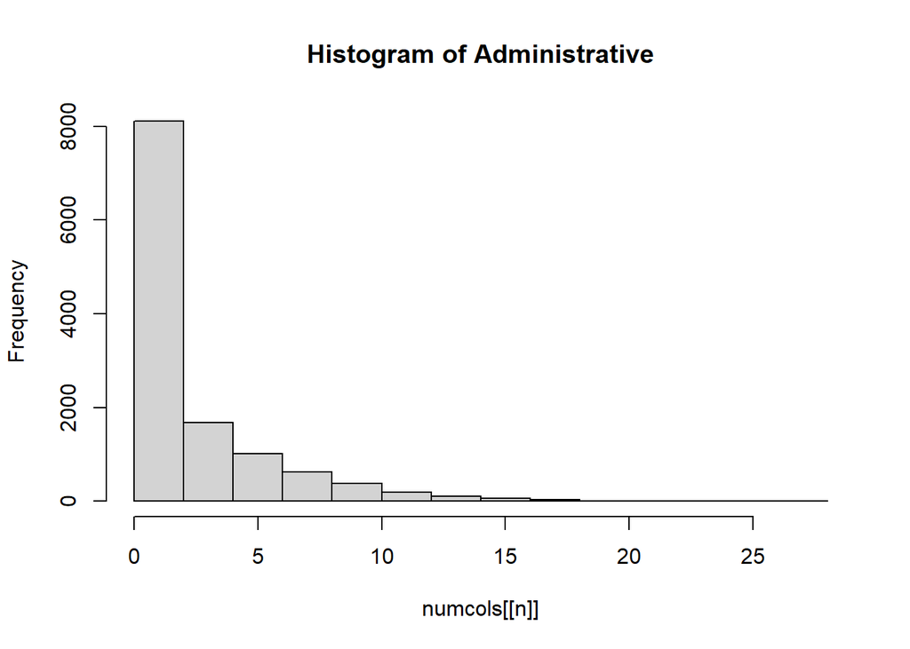

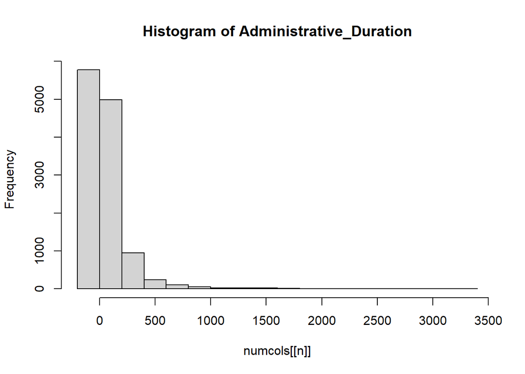

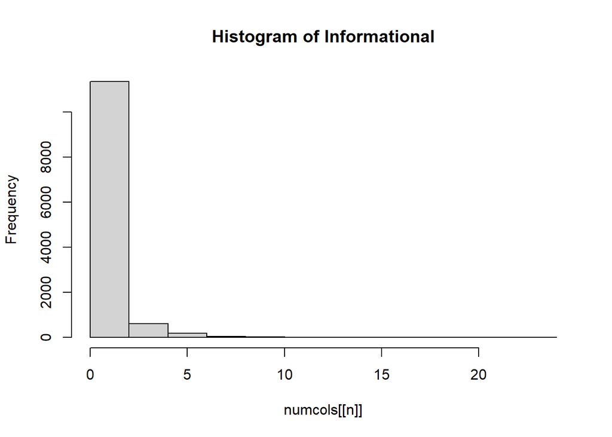

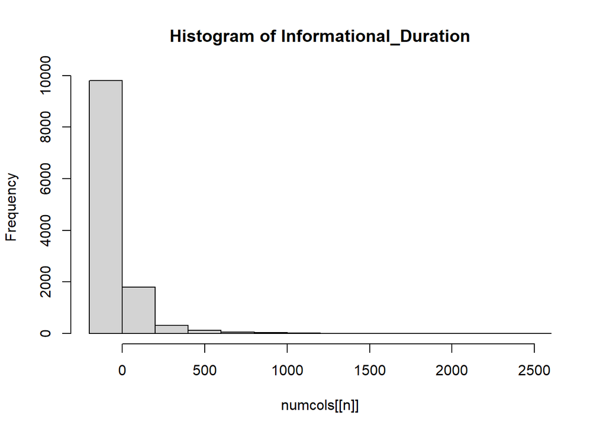

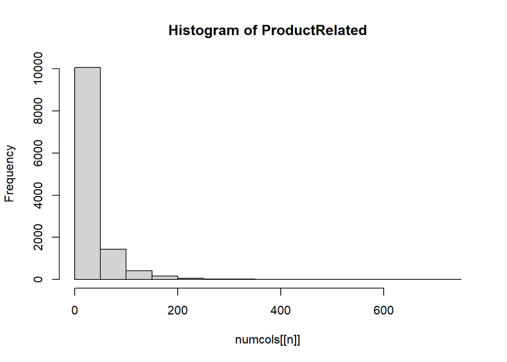

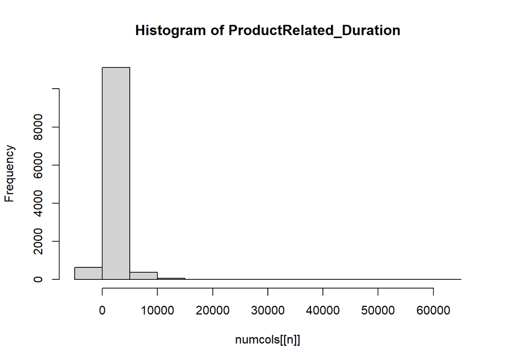

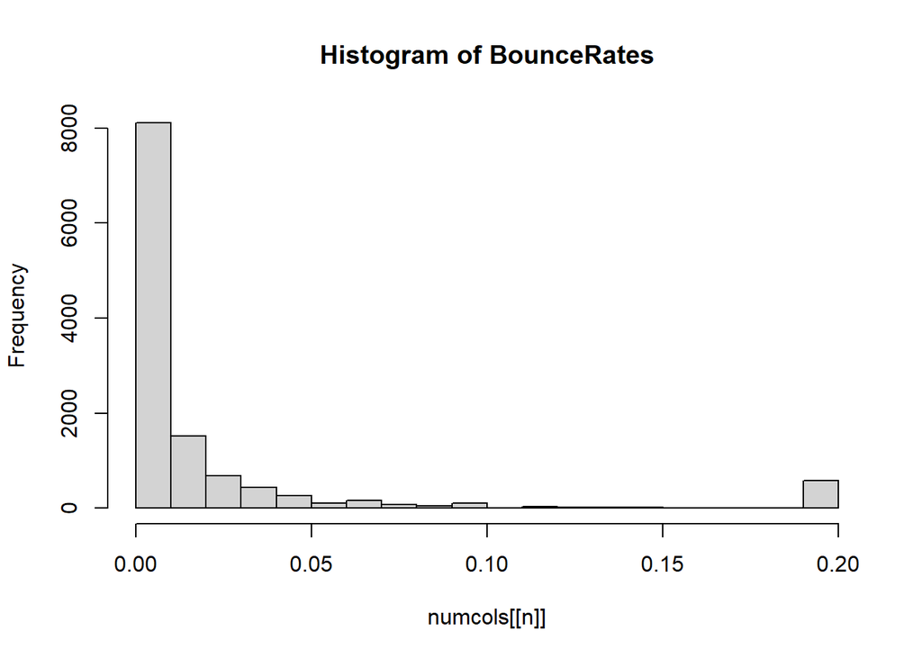

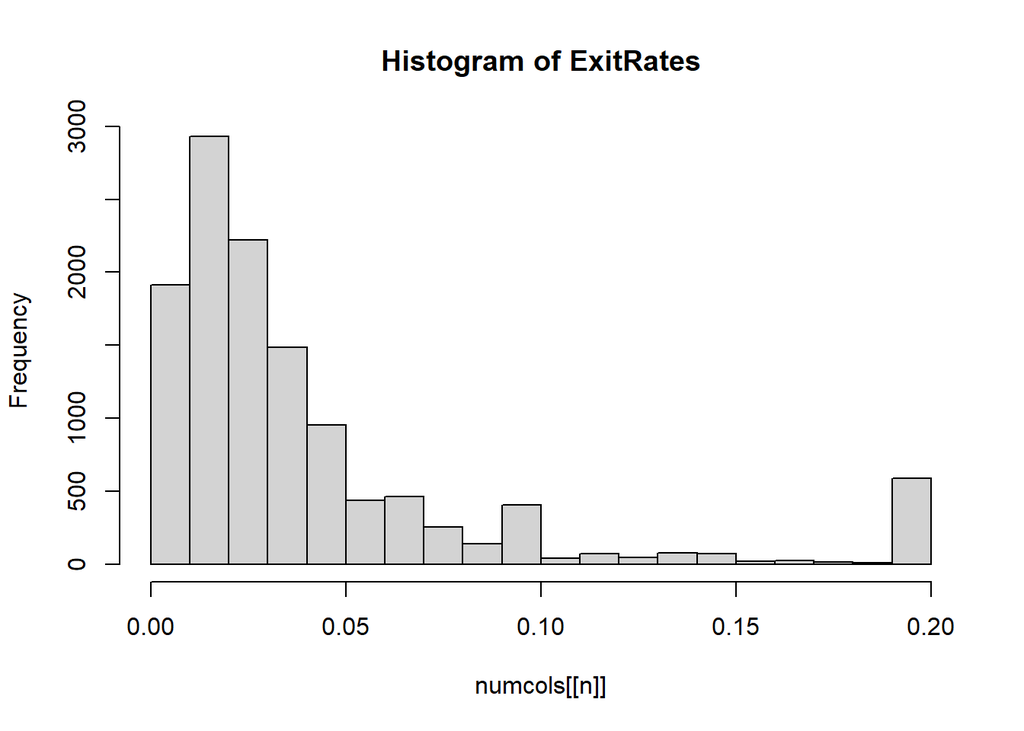

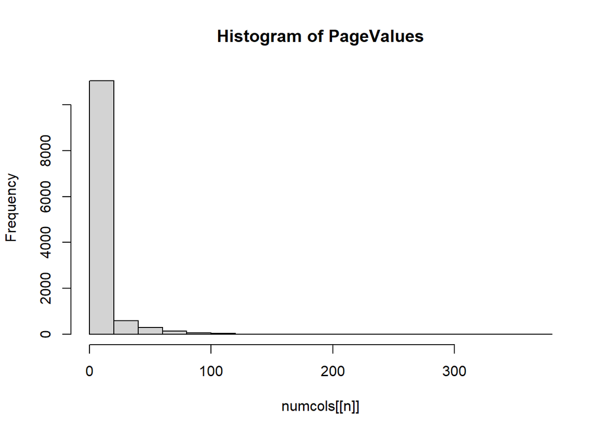

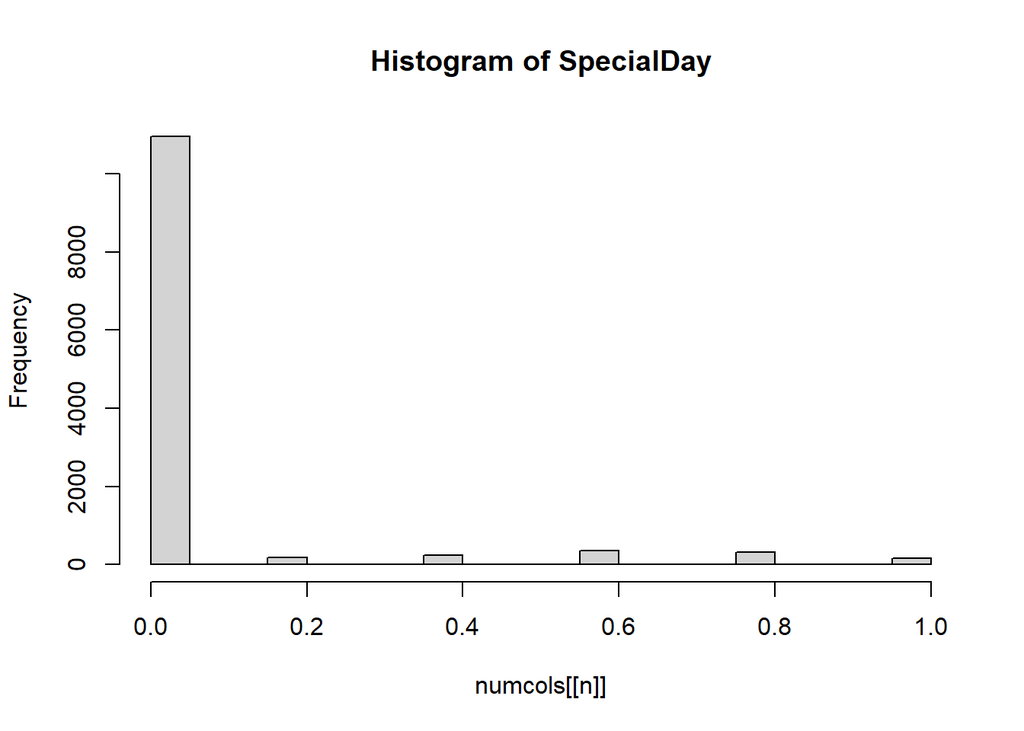

```r
invisible(lapply(names(numcols), function(n) hist(numcols[[n]],main = paste("Histogram of" , colnames(numcols[,n])))))
```

## bivariate analysis

### categorical vs categorical

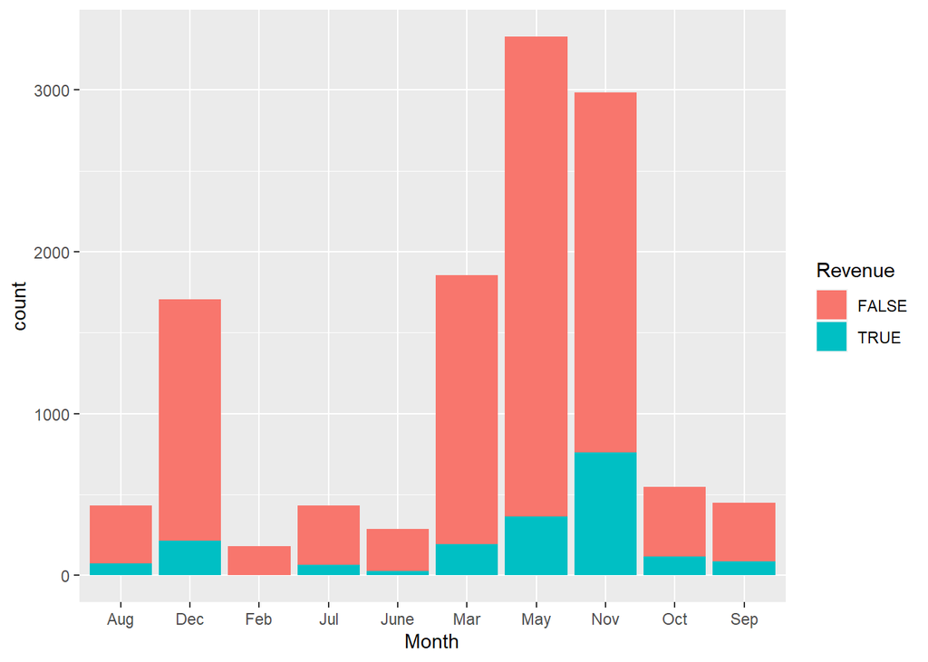

```r
# stacked bar chart
ggplot(ecomm,
       aes(x = Month,
           fill = Revenue)) +
  geom_bar(position = "stack")
```

November had the most revenue while February the least.

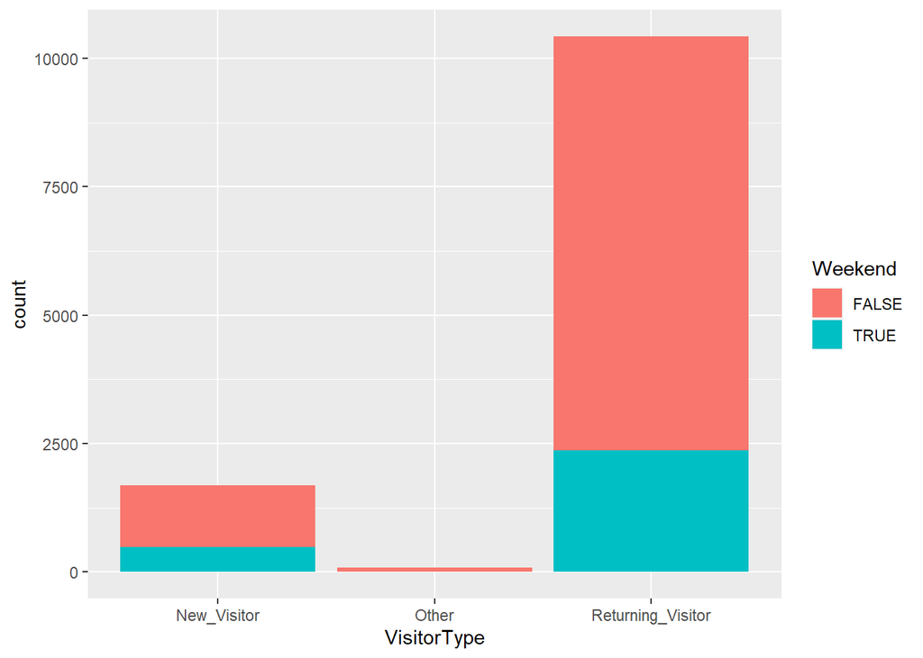

```r
# stacked bar chart
ggplot(ecomm,
       aes(x = VisitorType,
           fill = Weekend)) +
  geom_bar(position = "stack")
```

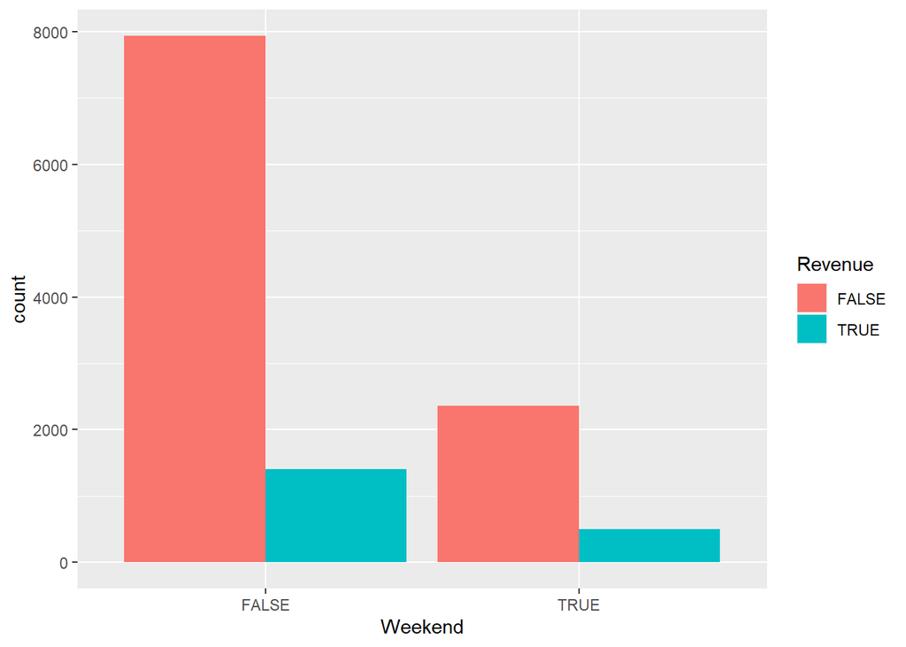

```r
ggplot(ecomm,
       aes(x = Weekend,
           fill = Revenue)) +
  geom_bar(position = "dodge")
```

More revenue was collected on weekdays compared to weekends

### numerical vs numerical

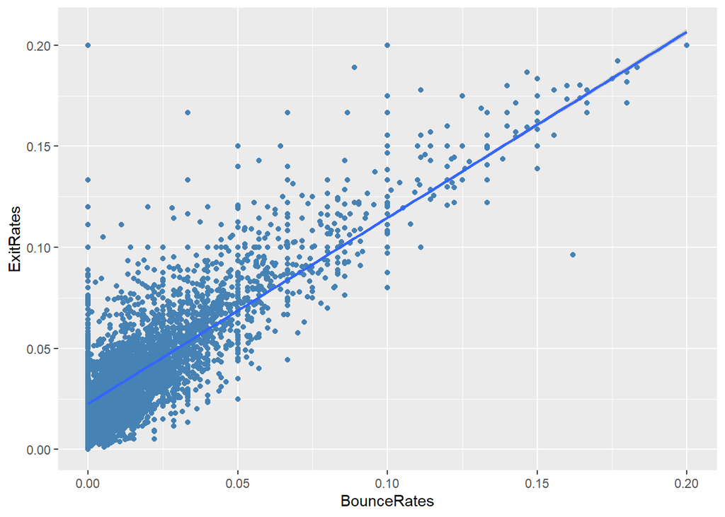

```r
# scatterplot with linear fit line
ggplot(ecomm,
       aes(x = BounceRates,
           y = ExitRates)) +
  geom_point(color= "steelblue") +
  geom_smooth(method = "lm")
```

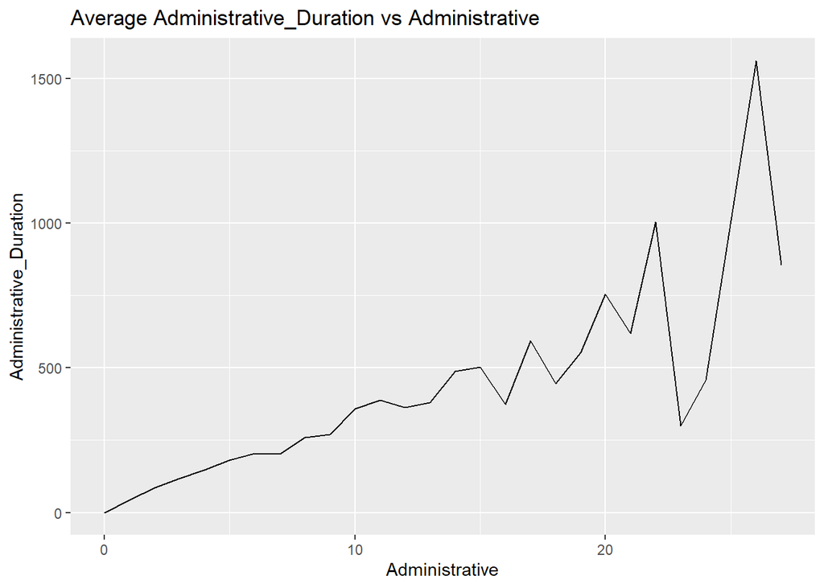

```r
df<- aggregate(Administrative_Duration~Administrative,data=ecomm,mean)
ggplot(data=df, aes(x=Administrative,y=Administrative_Duration))+geom_line()+xlab(label="Administrative")+ylab(label="Administrative_Duration")+labs(title="Average Administrative_Duration vs Administrative ")
```

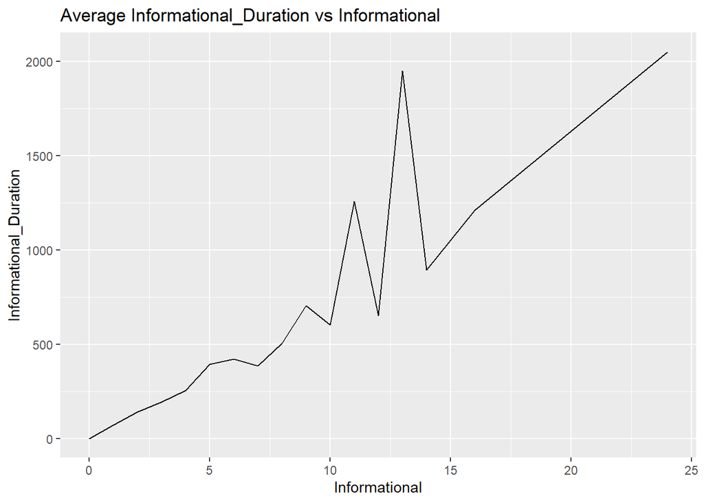

```r
df1<- aggregate(Informational_Duration~Informational,data=ecomm,mean)
ggplot(data=df1, aes(x=Informational,y=Informational_Duration))+geom_line()+xlab(label="Informational")+ylab(label="Informational_Duration")+labs(title="Average Informational_Duration vs Informational ")
```

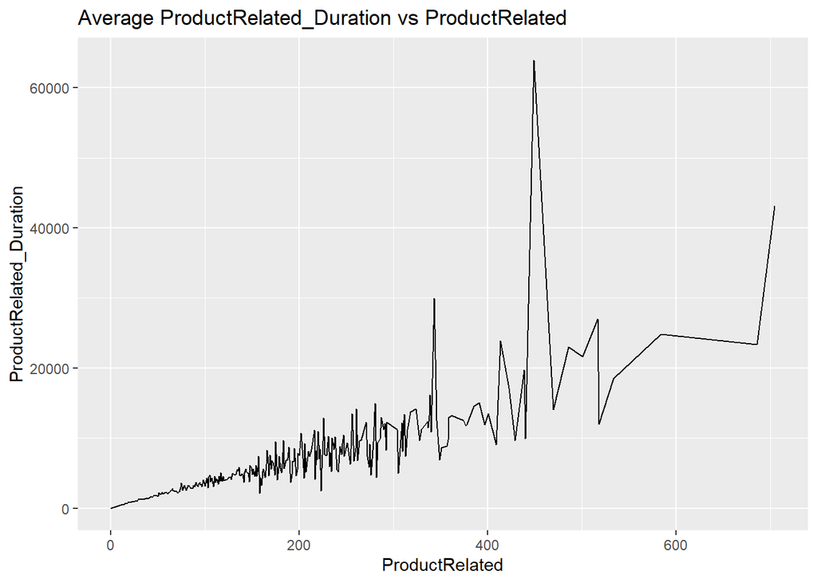

```r
df2<- aggregate(ProductRelated_Duration~ProductRelated,data=ecomm,mean)
ggplot(data=df2, aes(x=ProductRelated,y=ProductRelated_Duration))+geom_line()+xlab(label="ProductRelated")+ylab(label="ProductRelated_Duration")+labs(title="Average ProductRelated_Duration vs ProductRelated ")
```

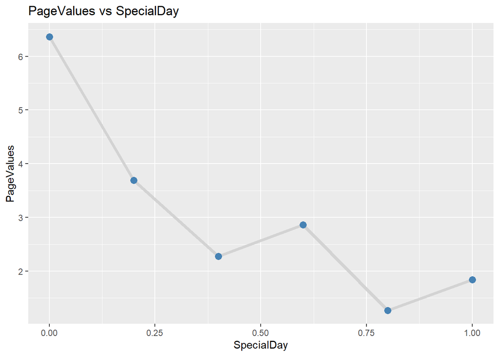

```r
df3<- aggregate(PageValues~SpecialDay,data=ecomm,mean)
ggplot(data=df3, aes(x=SpecialDay,y=PageValues)) +
  geom_line(size = 1.5,
            color = "lightgrey") +
  geom_point(size = 3,
             color = "steelblue")+xlab(label="SpecialDay")+ylab(label="PageValues")+labs(title="PageValues vs SpecialDay")
```

The page values had an inverse relation with the special day rating

### categorical vs numerical

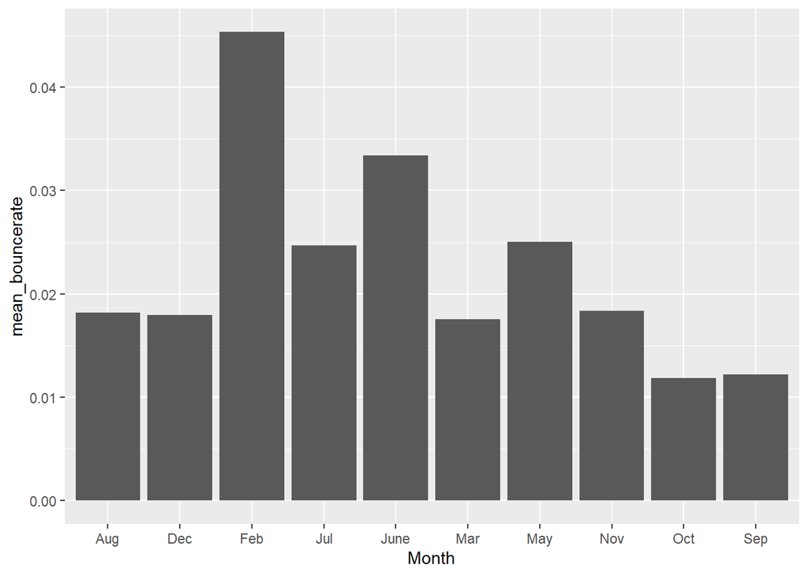

```r
# calculate mean bouncerate for each month
library(dplyr)
plotdata <- ecomm %>%
  group_by(Month) %>%
  summarize(mean_bouncerate = mean(BounceRates))

# plot mean salaries
ggplot(plotdata,
       aes(x = Month,
           y = mean_bouncerate)) +
  geom_bar(stat = "identity")
```

February had the highest average bounce rates while october and september had the least

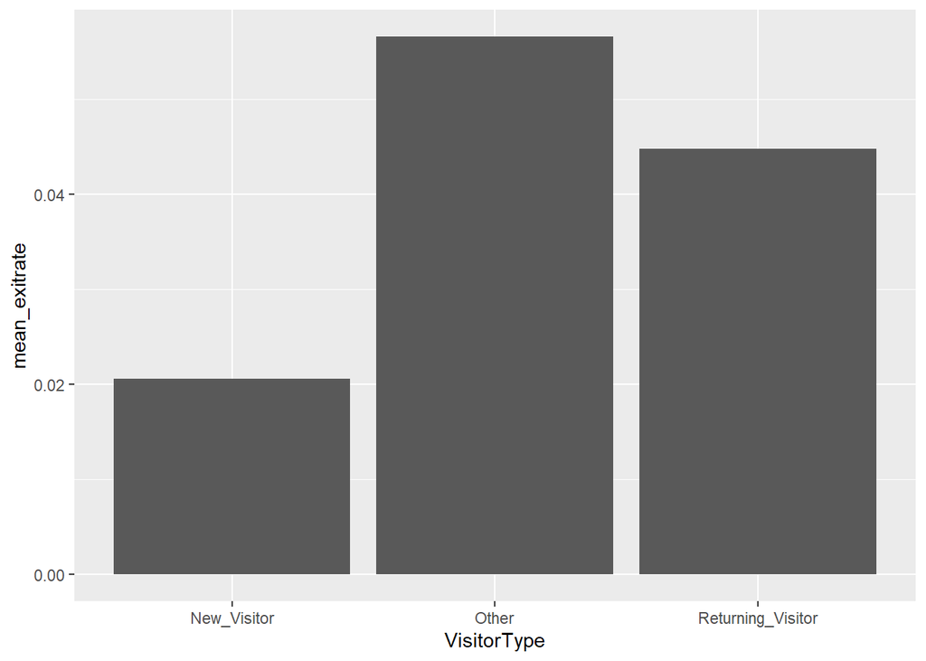

```r
plotdata <- ecomm %>%
  group_by(VisitorType) %>%
  summarize(mean_exitrate = mean(ExitRates))

# plot mean salaries
ggplot(plotdata,
       aes(x = VisitorType,
           y = mean_exitrate)) +
  geom_bar(stat = "identity")
```

‘other’ category had the highest exit rates follwed by the returning visitors.

## Multivariate analysis

### correlation heatmap for numerical columns

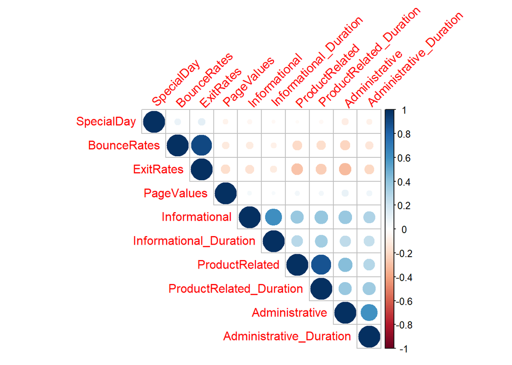

```r
library(corrplot)
corrs<- cor(numcols, method="pearson")
corrplot(corrs,type="upper",order="hclust",tl.srt=45)
```

```r
corrs
```

```
##                         Administrative Administrative_Duration Informational
## Administrative              1.00000000              0.60040965    0.37528761
## Administrative_Duration     0.60040965              1.00000000    0.30143630
## Informational               0.37528761              0.30143630    1.00000000
## Informational_Duration      0.25478602              0.23718986    0.61867795
## ProductRelated              0.42819151              0.28678391    0.37260472
## ProductRelated_Duration     0.37102722              0.35351379    0.38608372
## BounceRates                -0.21366664             -0.13733340   -0.10950530
## ExitRates                  -0.31127413             -0.20202445   -0.15956681
## PageValues                  0.09692097              0.06616837    0.04739015
## SpecialDay                 -0.09707210             -0.07473689   -0.04937677
##                         Informational_Duration ProductRelated
## Administrative                      0.25478602     0.42819151
## Administrative_Duration             0.23718986     0.28678391
## Informational                       0.61867795     0.37260472
## Informational_Duration              1.00000000     0.27906195
## ProductRelated                      0.27906195     1.00000000
## ProductRelated_Duration             0.34658069     0.86030819
## BounceRates                        -0.07015947    -0.19351577
## ExitRates                          -0.10293268    -0.28616321
## PageValues                          0.03006416     0.05411549
## SpecialDay                         -0.03129304    -0.02593062
##                         ProductRelated_Duration BounceRates  ExitRates
## Administrative                       0.37102722 -0.21366664 -0.3112741
## Administrative_Duration              0.35351379 -0.13733340 -0.2020245
## Informational                        0.38608372 -0.10950530 -0.1595668
## Informational_Duration               0.34658069 -0.07015947 -0.1029327
## ProductRelated                       0.86030819 -0.19351577 -0.2861632
## ProductRelated_Duration              1.00000000 -0.17437550 -0.2453340
## BounceRates                         -0.17437550  1.00000000  0.9033582
## ExitRates                           -0.24533401  0.90335819  1.0000000
## PageValues                           0.05084062 -0.11599198 -0.1735715
## SpecialDay                          -0.03821065  0.08783999  0.1167838
##                          PageValues  SpecialDay
## Administrative           0.09692097 -0.09707210
## Administrative_Duration  0.06616837 -0.07473689
## Informational            0.04739015 -0.04937677
## Informational_Duration   0.03006416 -0.03129304
## ProductRelated           0.05411549 -0.02593062
## ProductRelated_Duration  0.05084062 -0.03821065
## BounceRates             -0.11599198  0.08783999
## ExitRates               -0.17357154  0.11678376
## PageValues               1.00000000 -0.06453271
## SpecialDay              -0.06453271  1.00000000
```

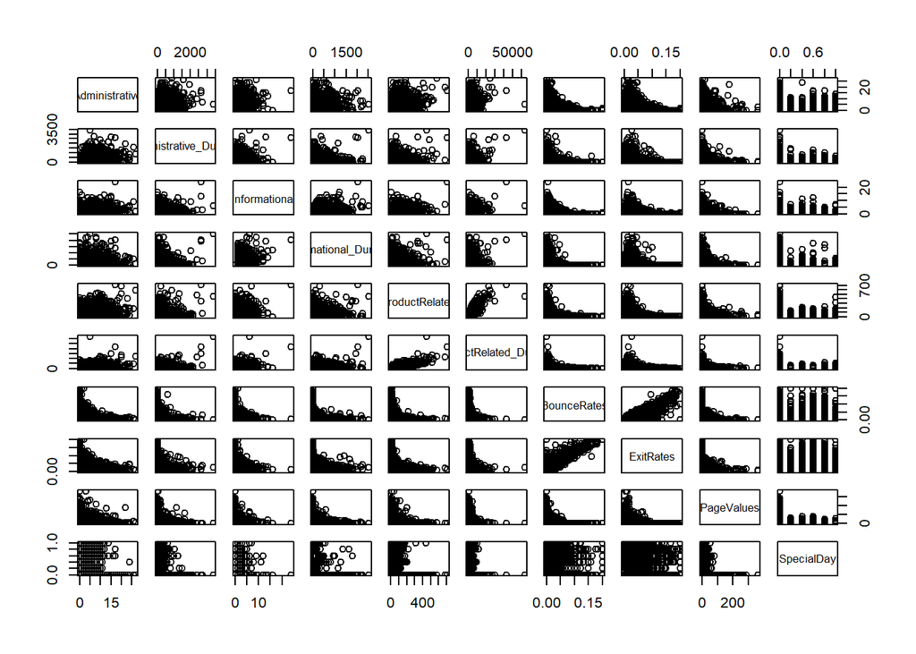

```r
pairs(numcols)
```

the relations on the pair plots could not be seen clearly like on the heatmap.

# Solution Implementation

## label encoding categorical variables

```r
library(superml)
label <- LabelEncoder$new()
label$fit(ecomm$Month)
ecomm$Month <- label$fit_transform(ecomm$Month)
label$fit(ecomm$VisitorType)
ecomm$VisitorType <- label$fit_transform(ecomm$VisitorType)
ecomm$Weekend<- as.integer(ecomm$Weekend)
ecomm$Revenue<- as.integer(ecomm$Revenue)
```

## Normalizing the data

```r
#define Min-Max normalization function
min_max_norm <- function(x) {
    (x - min(x)) / (max(x) - min(x))
  }

#apply Min-Max normalization
ecomm_norm <- as.data.frame(lapply(ecomm[1:17], min_max_norm))
head(ecomm_norm)
```

```
##   Administrative Administrative_Duration Informational Informational_Duration
## 1              0                       0             0                      0
## 2              0                       0             0                      0
## 3              0                       0             0                      0
## 4              0                       0             0                      0
## 5              0                       0             0                      0
## 6              0                       0             0                      0
##   ProductRelated ProductRelated_Duration BounceRates ExitRates PageValues
## 1    0.001418440            0.000000e+00  1.00000000  1.000000          0
## 2    0.002836879            1.000414e-03  0.00000000  0.500000          0
## 3    0.001418440            0.000000e+00  1.00000000  1.000000          0
## 4    0.002836879            4.168391e-05  0.25000000  0.700000          0
## 5    0.014184397            9.808746e-03  0.10000000  0.250000          0
## 6    0.026950355            2.410633e-03  0.07894737  0.122807          0
##   SpecialDay Month OperatingSystems    Browser Region TrafficType VisitorType
## 1          0     0        0.0000000 0.00000000  0.000  0.00000000           0
## 2          0     0        0.1428571 0.08333333  0.000  0.05263158           0
## 3          0     0        0.4285714 0.00000000  1.000  0.10526316           0
## 4          0     0        0.2857143 0.08333333  0.125  0.15789474           0
## 5          0     0        0.2857143 0.16666667  0.000  0.15789474           0
## 6          0     0        0.1428571 0.08333333  0.000  0.10526316           0
##   Weekend
## 1       0
## 2       0
## 3       0
## 4       0
## 5       1
## 6       0
```

## Dimensionality reduction

```r
library(factoextra)
```

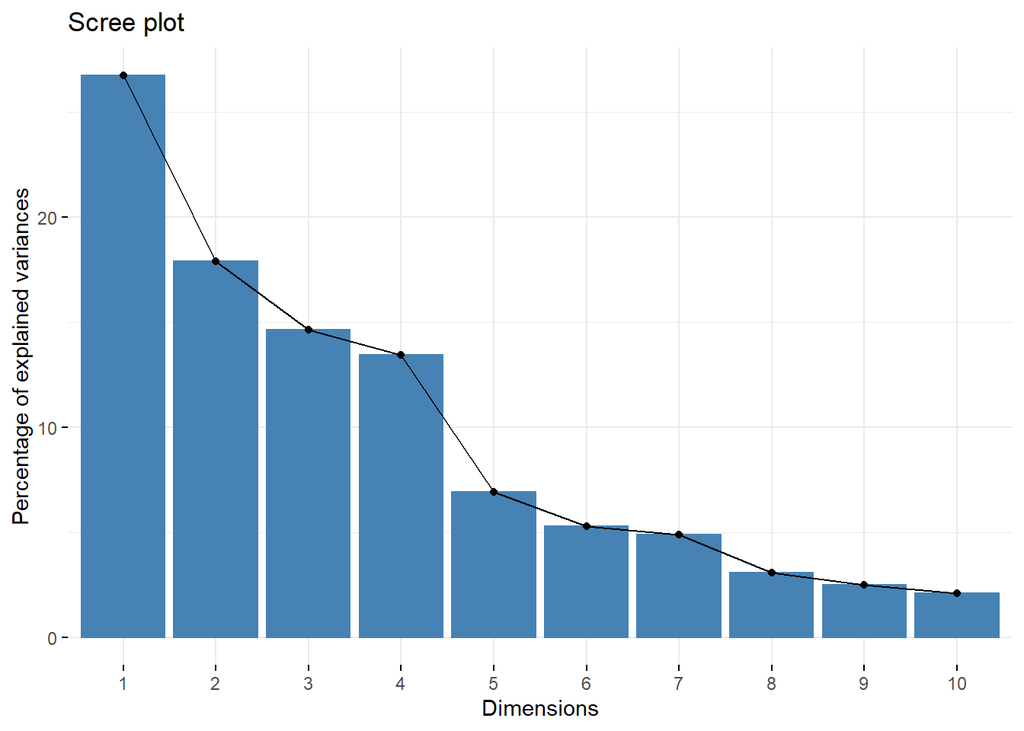

```r
res.pca <- prcomp(ecomm_norm)
fviz_eig(res.pca)
```

```r
summary(res.pca)
```

```
## Importance of components:
##                           PC1    PC2    PC3    PC4    PC5     PC6     PC7
## Standard deviation     0.4243 0.3471 0.3138 0.3007 0.2154 0.18822 0.18090
## Proportion of Variance 0.2677 0.1791 0.1464 0.1344 0.0690 0.05267 0.04865
## Cumulative Proportion  0.2677 0.4468 0.5932 0.7277 0.7967 0.84933 0.89798
##                            PC8     PC9    PC10    PC11    PC12    PC13    PC14
## Standard deviation     0.14399 0.12926 0.11811 0.06954 0.06547 0.05255 0.04967
## Proportion of Variance 0.03082 0.02484 0.02074 0.00719 0.00637 0.00411 0.00367
## Cumulative Proportion  0.92881 0.95365 0.97439 0.98158 0.98795 0.99205 0.99572
##                           PC15    PC16    PC17
## Standard deviation     0.04021 0.03291 0.01331
## Proportion of Variance 0.00240 0.00161 0.00026
## Cumulative Proportion  0.99813 0.99974 1.00000
```

```r
ecomm.new<- res.pca$x
```

with 7 principal components we have 89.7% explained variance which is a good percentage.

## K-means Clustering

### finding optimum value for k

```r
library(cluster)
set.seed(123)

#fviz_nbclust(ecomm.new[,1:7], kmeans, method = "wss")
```

#### silhoutte method

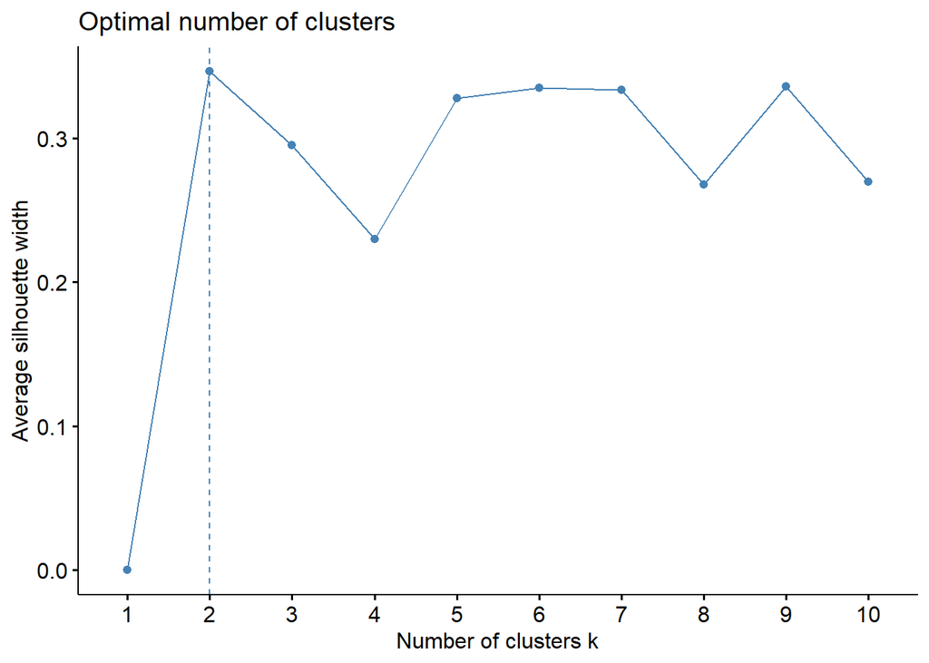

```r
fviz_nbclust(ecomm.new[,1:7], kmeans, method = "silhouette")
```